# Homework 1 - Julianna

Julianna Szabo

3/16/2021

# Exercise 1

We have to import the data

```r
data <- as_tibble(ISLR::OJ)
h2o_data <- as.h2o(data)
```

## A, Train and test data and build a decision tree for reference

```r
## Train and test data
splitted_data <- h2o.splitFrame(h2o_data, ratios = 0.75, seed = my_seed)
data_train <- splitted_data[[1]]
data_test <- splitted_data[[2]]
```

```r
y <- "Purchase"
X <- setdiff(names(h2o_data), y)

## Simple decision tree
gbm_params_1tree = list(max_depth = seq(2, 10))

### Train and validate a cartesian grid of GBMs
gbm_grid = h2o.grid("gbm", x = X, y = y,
                    grid_id = "gbm_grid_1tree",
                    training_frame = data_train,
                    ntrees = 1, min_rows = 1,
                    sample_rate = 1, col_sample_rate = 1,
                    learn_rate = .01, seed = my_seed,
                    hyper_params = gbm_params_1tree)
```

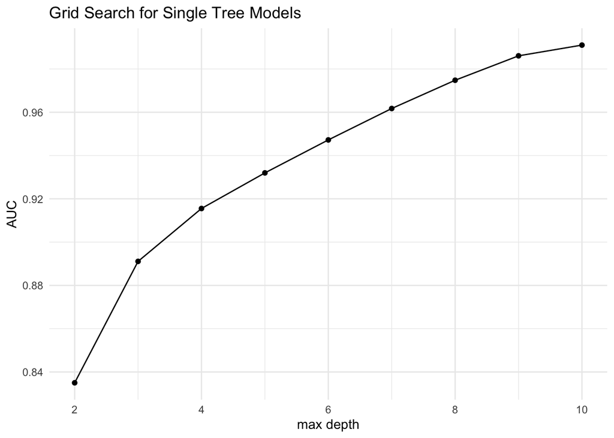

```r
gbm_gridperf = h2o.getGrid(grid_id = "gbm_grid_1tree",
                           sort_by = "auc",
                           decreasing = TRUE)

ggplot(as.data.frame(sapply(gbm_gridperf@summary_table, as.numeric))) +
  geom_point(aes(max_depth, auc)) +
  geom_line(aes(max_depth, auc, group=1)) +
  labs(x="max depth", y="AUC", title="Grid Search for Single Tree Models")
```

```r
data_1tree =
  h2o.gbm(x = X, y = y,
          training_frame = data_train,
          model_id = "data_1tree",
          ntrees = 1, min_rows = 1,
          sample_rate = 1, col_sample_rate = 1,
          max_depth = 4,
          stopping_rounds = 3, stopping_tolerance = 0.01,
          stopping_metric = "AUC",
          seed = 1)
```

```r
dataH2oTree = h2o.getModelTree(model = data_1tree, tree_number = 1)

source("Plotting_h2o_tree.R")

DataTree = createDataTree(dataH2oTree)

GetEdgeLabel <- function(node) {return (node$edgeLabel)}
GetNodeShape <- function(node) {switch(node$type,
                                       split = "diamond", leaf = "oval")}
GetFontName <- function(node) {switch(node$type,
                                      split = 'Palatino-bold',
                                      leaf = 'Palatino')}
SetEdgeStyle(DataTree, fontname = 'Palatino-italic',
             label = GetEdgeLabel, labelfloat = TRUE,
             fontsize = "26", fontcolor='royalblue4')
SetNodeStyle(DataTree, fontname = GetFontName, shape = GetNodeShape,
             fontsize = "26", fontcolor='royalblue4',
             height="0.75", width="1")

SetGraphStyle(DataTree, rankdir = "LR", dpi=70.)

plot(DataTree, output = "graph")
```

[interactive chart not shown]

Looking at the model it can be seen that Loyal CH is the most comonly used factor when splitting. This makes sense since this would dramatically increase which brand one buys. The other two variables that are used more than once are PriceDiff and SalePriceMM, which are both related to pricing. Meaning in some cases brand loyalty could be affected by pricing.

## B, Tree ensemble models

```r
## Random forest

rf_params <- list(
  ntrees = c(10, 50, 100, 300),
  mtries = c(2, 4, 6, 8),
  sample_rate = c(0.2, 0.632, 1),
  max_depth = c(10, 20)
)

rf_grid <- h2o.grid(
  "randomForest",
  x = X, y = y,
  training_frame = data_train,
  grid_id = "rf",
  nfolds = 5,
  seed = my_seed,
  hyper_params = rf_params
)
h2o.getGrid(rf_grid@grid_id, "auc", decreasing = TRUE)
```

```
## H2O Grid Details
## ================
##
## Grid ID: rf
## Used hyper parameters:
##   -  max_depth
##   -  mtries
##   -  ntrees
##   -  sample_rate
## Number of models: 96
## Number of failed models: 0
##
## Hyper-Parameter Search Summary: ordered by decreasing auc
##   max_depth mtries ntrees sample_rate   model_ids                auc
## 1        10      8    300         0.2 rf_model_31 0.8909589237996302
## 2        20      8    300         0.2 rf_model_32 0.8907008500101269
## 3        10      8    100         0.2 rf_model_23 0.8888747329426292
## 4        20      8    100         0.2 rf_model_24 0.8888681994289709
## 5        10      8     50         0.2 rf_model_15 0.8885088561777639
##
## ---
##    max_depth mtries ntrees sample_rate   model_ids                auc
## 91        20      8     10       0.632 rf_model_40 0.8544561829906505
## 92        20      6     10       0.632 rf_model_38 0.8544431159633339
## 93        20      8     50         1.0 rf_model_80 0.8530090097153348
## 94        20      6     10         1.0 rf_model_70 0.8459887492894804
## 95        20      4     10         1.0 rf_model_68 0.8417190981137747
## 96        20      8     10         1.0 rf_model_72 0.8411735497233057
```

```r
best_rf <- h2o.getModel(
  h2o.getGrid(rf_grid@grid_id, "auc", decreasing = TRUE)@model_ids[[1]]
)
best_rf
```

```
## Model Details:
## ==============
##
## H2OBinomialModel: drf
## Model ID:  rf_model_31
## Model Summary:
##   number_of_trees number_of_internal_trees model_size_in_bytes min_depth
## 1             300                      300              157306         6
##   max_depth mean_depth min_leaves max_leaves mean_leaves
## 1        10    9.51667         22         59    37.01667
##
##
## H2OBinomialMetrics: drf
## ** Reported on training data. **
## ** Metrics reported on Out-Of-Bag training samples **
##
## MSE:  0.1240634
## RMSE:  0.3522263
## LogLoss:  0.4061204
## Mean Per-Class Error:  0.1775188
## AUC:  0.8900867
## AUCPR:  0.8380569
## Gini:  0.7801734
## R^2:  0.4786384
##
## Confusion Matrix (vertical: actual; across: predicted) for F1-optimal threshold:
##         CH  MM    Error      Rate
## CH     406  83 0.169734   =83/489
## MM      58 255 0.185304   =58/313
## Totals 464 338 0.175810  =141/802
##
## Maximum Metrics: Maximum metrics at their respective thresholds
##                         metric threshold      value idx
## 1                       max f1  0.388216   0.783410 203
## 2                       max f2  0.214885   0.834323 261
## 3                 max f0point5  0.685504   0.820017 124
## 4                 max accuracy  0.527610   0.834165 168
## 5                max precision  0.958333   0.972222  18
## 6                   max recall  0.004125   1.000000 396
## 7              max specificity  0.989757   0.997955   0
```

[output cut: 69 more lines]

```
## ---
##                   mean          sd cv_1_valid cv_2_valid cv_3_valid cv_4_valid
## pr_auc      0.83921933    0.076522 0.82384026 0.84952295 0.90794134 0.71703124
## precision    0.7753169  0.06745679  0.7903226  0.8405797  0.8023256  0.6615385
## r2          0.47326636 0.086762674  0.4784373 0.48468474 0.52307445 0.32766485
## recall       0.8391346 0.056909066  0.7903226 0.79452056 0.88461536  0.8113208
## rmse        0.35114163 0.022704288  0.3458668 0.35367462 0.34396794  0.3871403
## specificity 0.84538364  0.04356644  0.8839286 0.89320385  0.8172043  0.7904762
##             cv_5_valid
## pr_auc      0.89776105
## precision    0.7818182
## r2          0.55247045
## recall       0.9148936
## rmse        0.32505846
## specificity 0.84210527
```

```r
h2o.auc(h2o.performance(best_rf))
```

```
## [1] 0.8900867
```

```r
## GBM

gbm_params <- list(
  learn_rate = c(0.01, 0.05, 0.1, 0.3),
  ntrees = c(10, 50, 100, 300),
  max_depth = c(2, 5),
  sample_rate = c(0.2, 0.5, 0.8, 1)
)

gbm_grid <- h2o.grid(
  "gbm", x = X, y = y,
  grid_id = "gbm",
  training_frame = data_train,
  nfolds = 5,
  seed = my_seed,
  hyper_params = gbm_params
)
(h2o.getGrid(grid_id = gbm_grid@grid_id, sort_by = "auc", decreasing = TRUE))
```

```
## H2O Grid Details
## ================
##
## Grid ID: gbm
## Used hyper parameters:
##   -  learn_rate
##   -  max_depth
##   -  ntrees
##   -  sample_rate
## Number of models: 128
## Number of failed models: 0
##
## Hyper-Parameter Search Summary: ordered by decreasing auc
##   learn_rate max_depth ntrees sample_rate    model_ids                auc
## 1        0.3         2     10         0.2  gbm_model_4 0.8983744618018124
## 2        0.1         2     50         0.8 gbm_model_75  0.897711310165494
## 3       0.05         2    100         0.8 gbm_model_82 0.8971102269089294
## 4       0.05         2    100         0.5 gbm_model_50 0.8966038796004102
## 5       0.05         2    100         0.2 gbm_model_18 0.8958721260706796
##
## ---
##     learn_rate max_depth ntrees sample_rate    model_ids                auc
## 123       0.01         2     10         0.5 gbm_model_33 0.8382073345224329
## 124       0.01         2     10         0.8 gbm_model_65 0.8337906792894151
## 125       0.01         2     10         0.2  gbm_model_1 0.8336992100981987
## 126       0.01         2     10         1.0 gbm_model_97 0.8316868878914392
## 127        0.3         5    100         0.2 gbm_model_24 0.8187766649026179
## 128        0.3         5    300         0.2 gbm_model_32 0.7512299339461769
```

```r
best_gbm <- h2o.getModel(
  h2o.getGrid(grid_id = gbm_grid@grid_id, sort_by = "auc", decreasing = TRUE)@model_ids[[1]]
)

best_gbm
```

```
## Model Details:
## ==============
##
## H2OBinomialModel: gbm
## Model ID:  gbm_model_4
## Model Summary:
##   number_of_trees number_of_internal_trees model_size_in_bytes min_depth
## 1              10                       10                1067         2
##   max_depth mean_depth min_leaves max_leaves mean_leaves
## 1         2    2.00000          3          4     3.90000
##
##
## H2OBinomialMetrics: gbm
## ** Reported on training data. **
##
## MSE:  0.1176648
## RMSE:  0.343023
## LogLoss:  0.3810144
## Mean Per-Class Error:  0.1527241
## AUC:  0.9063388
## AUCPR:  0.8643993
## Gini:  0.8126776
## R^2:  0.5055275
##
## Confusion Matrix (vertical: actual; across: predicted) for F1-optimal threshold:
##         CH  MM    Error      Rate
## CH     424  65 0.132924   =65/489
## MM      54 259 0.172524   =54/313
## Totals 478 324 0.148379  =119/802
##
## Maximum Metrics: Maximum metrics at their respective thresholds
##                         metric threshold      value idx
## 1                       max f1  0.377188   0.813187  98
## 2                       max f2  0.255719   0.860729 126
## 3                 max f0point5  0.473351   0.809650  84
## 4                 max accuracy  0.377188   0.851621  98
## 5                max precision  0.958349   1.000000   0
## 6                   max recall  0.056481   1.000000 174
## 7              max specificity  0.958349   1.000000   0
## 8             max absolute_mcc  0.377188   0.690470  98
```

[output cut: 68 more lines]

```
## ---
##                   mean          sd cv_1_valid cv_2_valid cv_3_valid cv_4_valid
## pr_auc       0.8383937  0.08090804 0.79108155 0.86886483 0.90540606 0.72038794
## precision   0.78687644   0.0795891 0.74647886  0.7848101 0.85333335 0.67741936
## r2          0.47715053  0.09770725 0.49332136 0.47068137 0.50292087  0.3241551
## recall        0.837892 0.031508435  0.8548387 0.84931505 0.82051283  0.7924528
## rmse        0.34960112  0.02855892   0.340896 0.35844785 0.35116032  0.3881495
## specificity 0.85730684  0.04406612 0.83928573 0.83495146  0.8817204  0.8095238
##             cv_5_valid
## pr_auc      0.90622807
## precision   0.87234044
## r2            0.594674
## recall      0.87234044
## rmse        0.30935195
## specificity 0.92105263
```

```r
h2o.auc(h2o.performance(best_gbm))
```

```
## [1] 0.9063388
```

```r
## XG Boost

xgboost_params <- list(
  learn_rate = c(0.1, 0.3),
  ntrees = c(50, 100),
  max_depth = c(2, 5),
  gamma = c(0, 1, 2),
  sample_rate = c(0.5, 1)
)

xgboost_grid <- h2o.grid(
  "xgboost",
  x = X, y = y,
  grid_id = "xgboost",
  training_frame = data_train,
  nfolds = 5,
  seed = my_seed,
  hyper_params = xgboost_params
)
h2o.getGrid(grid_id = xgboost_grid@grid_id, sort_by = "auc", decreasing = TRUE)
```

```
## H2O Grid Details
## ================
##
## Grid ID: xgboost
## Used hyper parameters:
##   -  gamma
##   -  learn_rate
##   -  max_depth
##   -  ntrees
##   -  sample_rate
## Number of models: 48
## Number of failed models: 0
##
## Hyper-Parameter Search Summary: ordered by decreasing auc
##   gamma learn_rate max_depth ntrees sample_rate        model_ids
## 1   1.0        0.1         2     50         0.5  xgboost_model_2
## 2   2.0        0.1         2     50         0.5  xgboost_model_3
## 3   0.0        0.1         2     50         0.5  xgboost_model_1
## 4   2.0        0.1         2     50         1.0 xgboost_model_27
## 5   1.0        0.1         2     50         1.0 xgboost_model_26
##                  auc
## 1 0.8979857177391429
## 2 0.8970252912313713
## 3 0.8966071463572395
## 4 0.8960452641826248
## 5 0.8958002574204381
##
## ---
##    gamma learn_rate max_depth ntrees sample_rate        model_ids
## 43   0.0        0.3         5     50         1.0 xgboost_model_34
## 44   2.0        0.3         5    100         0.5 xgboost_model_24
## 45   1.0        0.3         5    100         0.5 xgboost_model_23
## 46   0.0        0.3         5     50         0.5 xgboost_model_10
## 47   0.0        0.3         5    100         1.0 xgboost_model_46
## 48   0.0        0.3         5    100         0.5 xgboost_model_22
##                   auc
## 43 0.8723547436575916
## 44 0.8720509352724801
## 45 0.8659388332451309
## 46  0.865180945660767
## 47 0.8602448760919135
## 48 0.8578503433361427
```

```r
best_xgboost <- h2o.getModel(
  h2o.getGrid(grid_id = xgboost_grid@grid_id, sort_by = "auc", decreasing = TRUE)@model_ids[[1]]
)

best_xgboost
```

```
## Model Details:
## ==============
##
## H2OBinomialModel: xgboost
## Model ID:  xgboost_model_2
## Model Summary:
##   number_of_trees
## 1              50
##
##
## H2OBinomialMetrics: xgboost
## ** Reported on training data. **
##
## MSE:  0.1064813
## RMSE:  0.3263147
## LogLoss:  0.3484091
## Mean Per-Class Error:  0.1417348
## AUC:  0.9222316
## AUCPR:  0.8869729
## Gini:  0.8444632
## R^2:  0.5525249
##
## Confusion Matrix (vertical: actual; across: predicted) for F1-optimal threshold:
##         CH  MM    Error      Rate
## CH     416  73 0.149284   =73/489
## MM      42 271 0.134185   =42/313
## Totals 458 344 0.143392  =115/802
##
## Maximum Metrics: Maximum metrics at their respective thresholds
##                         metric threshold      value idx
## 1                       max f1  0.382040   0.824962 207
## 2                       max f2  0.214856   0.871886 258
## 3                 max f0point5  0.741000   0.834039 118
## 4                 max accuracy  0.491762   0.857855 185
## 5                max precision  0.963115   1.000000   0
## 6                   max recall  0.041486   1.000000 374
## 7              max specificity  0.963115   1.000000   0
## 8             max absolute_mcc  0.382040   0.706235 207
## 9   max min_per_class_accuracy  0.394720   0.853035 203
## 10 max mean_per_class_accuracy  0.382040   0.858265 207
```

[output cut: 66 more lines]

```
## ---
##                   mean          sd cv_1_valid cv_2_valid cv_3_valid cv_4_valid
## pr_auc      0.84078056 0.068454176  0.7875466 0.85885394 0.90652806  0.7520267
## precision   0.77899796  0.09334202  0.7714286 0.78205127  0.7906977  0.6438356
## r2          0.49337268  0.07486235 0.51052064  0.4759862 0.51983553 0.37833652
## recall      0.85899174  0.02489745 0.87096775  0.8356164  0.8717949  0.8867925
## rmse        0.34463778 0.021983938 0.33506018 0.35664713 0.34513393 0.37226582
## specificity 0.83965904  0.07184941 0.85714287 0.83495146  0.8064516 0.75238097
##             cv_5_valid
## pr_auc       0.8989476
## precision   0.90697676
## r2          0.58218455
## recall      0.82978725
## rmse        0.31408188
## specificity 0.94736844
```

```r
h2o.auc(h2o.performance(best_xgboost))
```

```
## [1] 0.9222316
```

In this step, I’ve picked the best models from the grids built for the different models. I’ve decided to use AUC as the metric for evaluation, since it is the best one number summary of a classification summary. THe higher the AUC is the better the classification.

## C, Model comparison

```r
my_models <- list(
  data_1tree, best_rf, best_gbm, best_xgboost
)

auc_validation <- map_df(my_models, ~{
  tibble(model = .@model_id,
         AUC_train = h2o.auc(h2o.performance(., data_train)),
         AUC_test = h2o.auc(h2o.performance(., data_test)))}) %>%
  arrange(AUC_train)

auc_validation
```

```
## # A tibble: 4 x 3
##   model           AUC_train AUC_test
##   <chr>               <dbl>    <dbl>
## 1 gbm_model_4         0.906    0.884
## 2 data_1tree          0.916    0.862
## 3 xgboost_model_2     0.922    0.889
## 4 rf_model_31         0.961    0.888
```

## D, Plot ROC curve for the best model

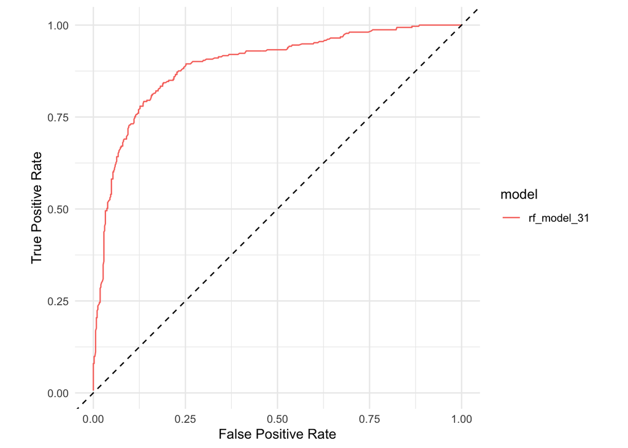

```r
getPerformanceMetrics <- function(model, newdata = NULL, xval = FALSE) {
  h2o.performance(model, newdata = newdata, xval = xval)@metrics$thresholds_and_metric_scores %>%
    as_tibble() %>%
    mutate(model = model@model_id)
}

plotROC <- function(performance_df) {
  ggplot(performance_df, aes(fpr, tpr, color = model)) +
    geom_path() +
    geom_abline(slope = 1, intercept = 0, linetype = "dashed") +
    coord_fixed() +
    labs(x = "False Positive Rate", y = "True Positive Rate")
}

best_rf_performance <- map_df(c(best_rf), getPerformanceMetrics, xval = TRUE)

plotROC(best_rf_performance)
```

The ROC curve looks very good. You can see that the line stays very close to zero on the FPR line while the TPR increases, which is good. Further, the line passes relatively close by 1 on the TPR axis, which is the goal we are trying to reach.

## E, Show variable importance

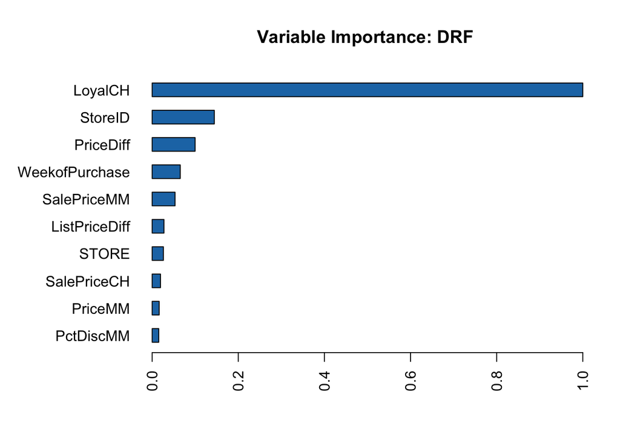

```r
h2o.varimp_plot(best_rf)
```

Looks like Loay to CH is by far the most important factor in the random forest. Others like StoreID and PriceDiff are much less important, although still more important than some others. This finding makes sense, since customers loayl to CH will be more likely to buy that brand despite some other factors. Interestingly, two of the three important variables were also the othes seen in the simple tree at the very beginning of this exercise.

```r
h2o.shutdown()
```

```
## Are you sure you want to shutdown the H2O instance running at http://localhost:54321/ (Y/N)?
```

# Exercise 2

First, we are loading the data.

```r
h2o.init()
```

[output not shown]

```r
data <- as_tibble(ISLR::Hitters) %>%
  drop_na(Salary) %>%
  mutate(log_salary = log(Salary), Salary = NULL)
h2o_data <- as.h2o(data)
y <- "log_salary"
X <- setdiff(names(h2o_data), y)
```

## A, Train 2 Random Forest models

```r
## 1, Random forest with 2 variables

rf_2_var <- h2o.randomForest(
  X, y,
  training_frame = h2o_data,
  model_id = "rf_2_var",
  mtries = 2,
  seed = my_seed
)
## 2, Random forest with 10 variables

rf_10_var <- h2o.randomForest(
  X, y,
  training_frame = h2o_data,
  model_id = "rf_2_var",
  mtries = 10,
  seed = my_seed
)
```

### Comparison of variable importance

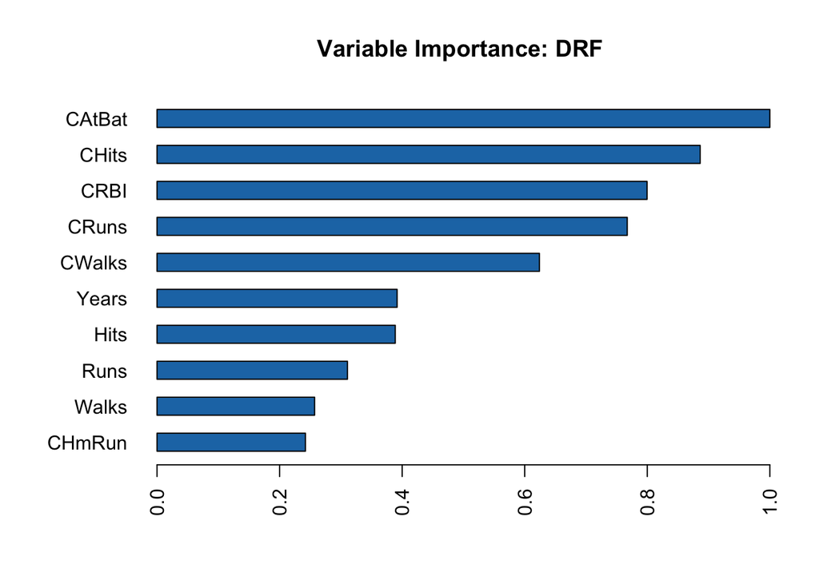

```r
h2o.varimp_plot(rf_2_var)
```

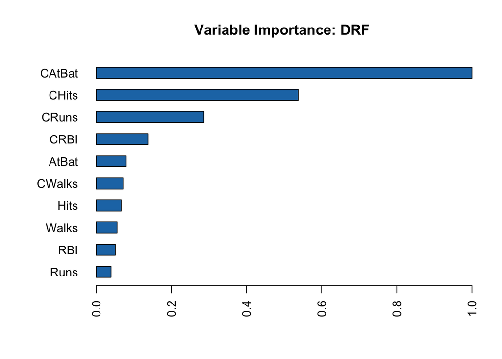

```r
h2o.varimp_plot(rf_10_var)
```

## B, Explanation of extreme difference in variable importance

In the one with 10 variables CAtBat is shown to be extremely more important than the others with a jump from almost 1 from 0.6. This could be explained that when 10 variables are picked randomly (this is what mtries = 10 means) then CAtBat will be included in more of the trees (default number of trees is 50). Therefore, its importance crystallizes out easier.

## C, Two GMB models

```r
## GBM sample_rate = 0.1

gbm_srate_01 <- h2o.gbm(
  x = X, y = y,
  model_id = "gbm_srate_01",
  training_frame = h2o_data,
  sample_rate = 0.1,
  seed = my_seed
)
## GBM sample_rate = 1

gbm_srate_1 <- h2o.gbm(
  x = X, y = y,
  model_id = "gbm_srate_1",
  training_frame = h2o_data,
  sample_rate = 1,
  seed = my_seed
)
```

### Comparison of variable importance

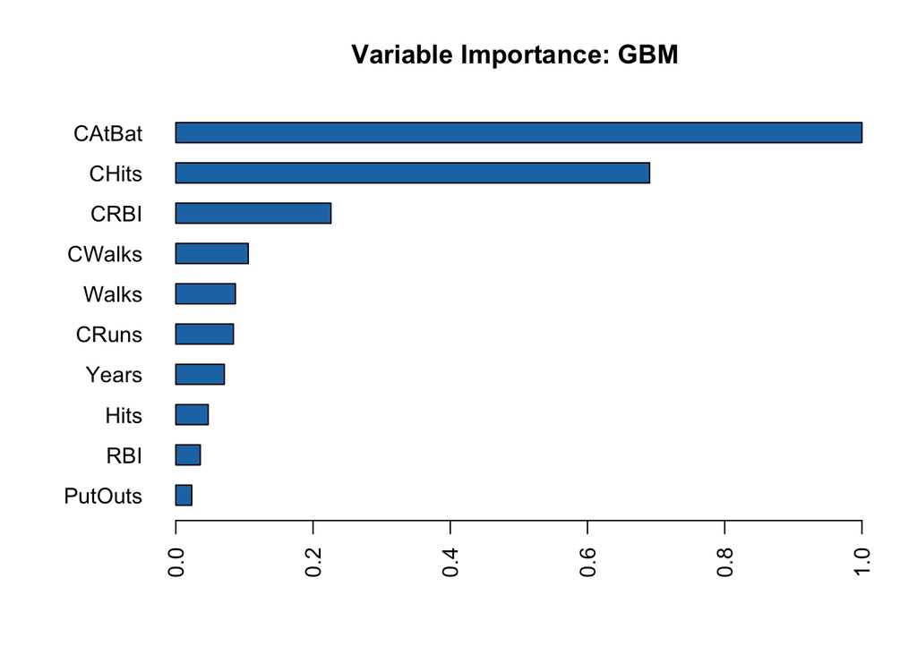

```r
h2o.varimp_plot(gbm_srate_01)
```

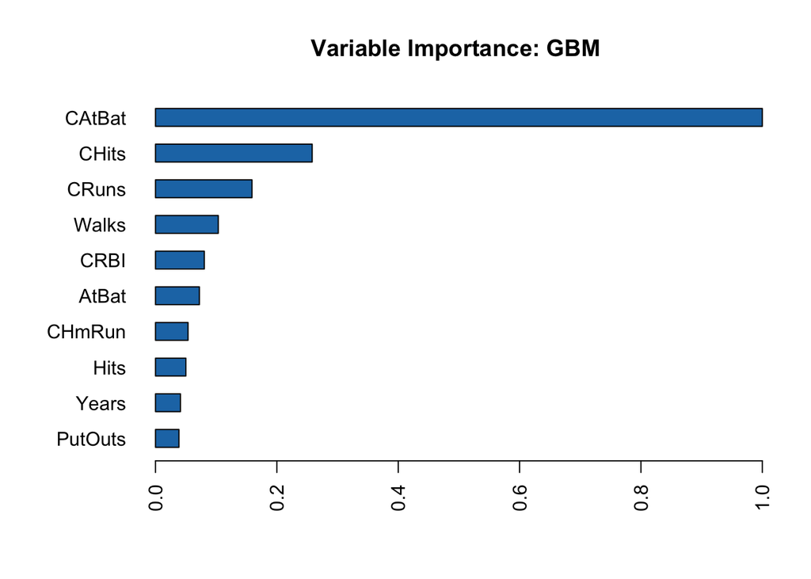

```r
h2o.varimp_plot(gbm_srate_1)
```

The one where the sample_rate is 1 has the more extreme values. This is because bootstrapping always completely resampled the data and therefore build every unrelated trees. With a sample_rate equal to 0.1 the generated datasets are closed to each other since only 10% of the data gets replaced. This means the data will be more unform and increase variables importance.

```r
h2o.shutdown()
```

```
## Are you sure you want to shutdown the H2O instance running at http://localhost:54321/ (Y/N)?
```

# Exercise 3

We load the new data.

```r
h2o.init()
```

[output not shown]

```r
# Load the data
data <- read_csv('https://raw.githubusercontent.com/Julianna-szabo/DS2_Homework1/main/KaggleV2-May-2016.csv')
# some data cleaning
data <- select(data, -one_of(c('PatientId', 'AppointmentID', 'Neighbourhood'))) %>%
  janitor::clean_names()

# for binary prediction, the target variable must be a factor + generate new variables
data <- mutate(
  data,
  no_show = factor(no_show, levels = c('Yes', 'No')),
  handcap = ifelse(handcap > 0, 1, 0),
  across(c(gender, scholarship, hipertension, alcoholism, handcap), factor),
  hours_since_scheduled = as.numeric(appointment_day - scheduled_day)
)

# clean up a little bit
data <- filter(data, between(age, 0, 95), hours_since_scheduled >= 0) %>%
  select(-one_of(c('scheduled_day', 'appointment_day', 'sms_received')))

h2o_data <- as.h2o(data)
```

## A, Create train / validation / test sets, cutting the data into 5% - 45% - 50% parts

```r
splitted_data <- h2o.splitFrame(h2o_data, ratios = c(0.05, 0.45), seed = my_seed)
data_train <- splitted_data[[1]]
data_valid <- splitted_data[[2]]
data_test <- splitted_data[[3]]
```

## B, Train a benchmark model of your choice (such as random forest, gbm or glm) evaluate it on the validation set.

```r
y <- 'no_show'
X <- setdiff(names(h2o_data), y)

glm_model <- h2o.glm(
  X, y,
  training_frame = data_train,
  model_id = "lm",
  lambda = 0,
  nfolds = 5,
  seed = my_seed,
  keep_cross_validation_predictions = TRUE
)
glm_model
```

```
## Model Details:
## ==============
##
## H2OBinomialModel: glm
## Model ID:  lm
## GLM Model: summary
##     family  link regularization number_of_predictors_total
## 1 binomial logit           None                          8
##   number_of_active_predictors number_of_iterations   training_frame
## 1                           8                    3 RTMP_sid_8266_10
##
## Coefficients: glm coefficients
##                   names coefficients standardized_coefficients
## 1             Intercept    -0.716883                 -0.931488
## 2              gender.M    -0.016067                 -0.016067
## 3         scholarship.1     0.141461                  0.141461
## 4        hipertension.1    -0.196679                 -0.196679
## 5          alcoholism.1     0.331939                  0.331939
## 6             handcap.1     0.332543                  0.332543
## 7                   age    -0.009900                 -0.226956
## 8              diabetes     0.267446                  0.069607
## 9 hours_since_scheduled     0.000405                  0.155812
##
## H2OBinomialMetrics: glm
## ** Reported on training data. **
##
## MSE:  0.1992184
## RMSE:  0.4463389
## LogLoss:  0.5864432
## Mean Per-Class Error:  0.4443854
## AUC:  0.5869575
## AUCPR:  0.3453123
## Gini:  0.1739149
## R^2:  0.01831463
## Residual Deviance:  4222.391
## AIC:  4240.391
##
## Confusion Matrix (vertical: actual; across: predicted) for F1-optimal threshold:
##         No  Yes    Error        Rate
## No     743 1838 0.712127  =1838/2581
```

[output cut: 83 more lines]

```
## ---
##                          mean           sd  cv_1_valid  cv_2_valid   cv_3_valid
## precision           0.3163048  0.011104523  0.30844155  0.31316727    0.3232143
## r2                0.013857904  0.007446459 0.009645394 0.021891335 0.0041571786
## recall             0.84699506   0.06444636  0.88785046   0.9072165    0.8116592
## residual_deviance    847.6968    56.165234    888.6836   805.44855      909.801
## rmse               0.44720635 0.0060150083     0.44957    0.444225   0.45630884
## specificity        0.27312294   0.09946855  0.20373832   0.2248996   0.27946767
##                    cv_4_valid  cv_5_valid
## precision          0.33186814  0.30483273
## r2                0.013047628 0.020547982
## recall             0.75124377  0.87700534
## residual_deviance    858.7811    775.7697
## rmse               0.44057703   0.4453509
## specificity        0.44322345  0.21428572
```

```r
h2o.rmse(h2o.performance(glm_model))
```

```
## [1] 0.4463389
```

```r
h2o.rmse(h2o.performance(glm_model, data_valid))
```

```
## [1] 0.4481576
```

Looks like this is a good model. The RMSE is 0.44 in the training set which is relatively good, especially because it doesn’t change much to the validation set. IT generated more False Positives than False Negatives. This is good because it means that we do not double book appointments. However, we only predict 18% of the ones that do not show up correctly. This is rather poor. Hopefully, it can be improved.

## C, Build at least 3 models of different families using cross validation, keeping cross validated predictions. You might also try deeplearning.

```r
## Random forest

rf_model <- h2o.randomForest(
  X, y,
  training_frame = data_train,
  model_id = 'rf_model',
  ntrees = 200,
  max_depth = 10,
  seed = my_seed,
  nfolds = 5,
  keep_cross_validation_predictions = TRUE
)
## GBM

gbm_model <- h2o.gbm(
  X, y,
  training_frame = data_train,
  model_id = 'gbm_model',
  ntrees = 200,
  max_depth = 5,
  learn_rate = 0.1,
  seed = my_seed,
  nfolds = 5,
  keep_cross_validation_predictions = TRUE
)
## Deeplearning

deeplearning_model <- h2o.deeplearning(
  X, y,
  training_frame = data_train,
  model_id = 'deeplearning',
  hidden = c(32, 8),
  seed = my_seed,
  nfolds = 5,
  keep_cross_validation_predictions = TRUE
)
```

## D, Evaluate validation set performance of each model

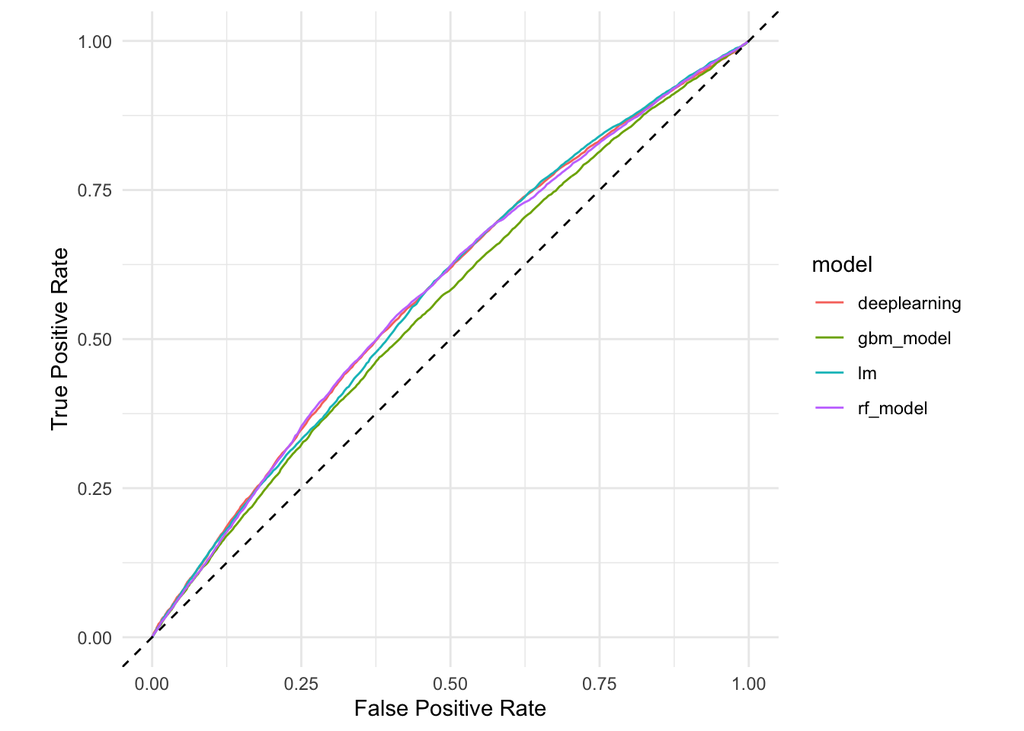

```r
getPerformanceMetrics <- function(model, newdata = NULL, xval = FALSE) {
  h2o.performance(model, newdata = newdata, xval = xval)@metrics$thresholds_and_metric_scores %>%
    as_tibble() %>%
    mutate(model = model@model_id)
}

plotROC <- function(performance_df) {
  ggplot(performance_df, aes(fpr, tpr, color = model)) +
    geom_path() +
    geom_abline(slope = 1, intercept = 0, linetype = 'dashed') +
    coord_fixed() +
    labs(x = 'False Positive Rate', y = 'True Positive Rate')
}

plotRP <- function(performance_df) {
  ggplot(performance_df, aes(precision, tpr, color = model)) +  # tpr = recall
    geom_line() +
    labs(x = 'Precision', y = 'Recall (TPR)')
}

my_models <- list(glm_model, rf_model, gbm_model, deeplearning_model)
all_performance <- map_df(c(my_models), getPerformanceMetrics, newdata = data_valid, xval = TRUE)
plotROC(all_performance)
```

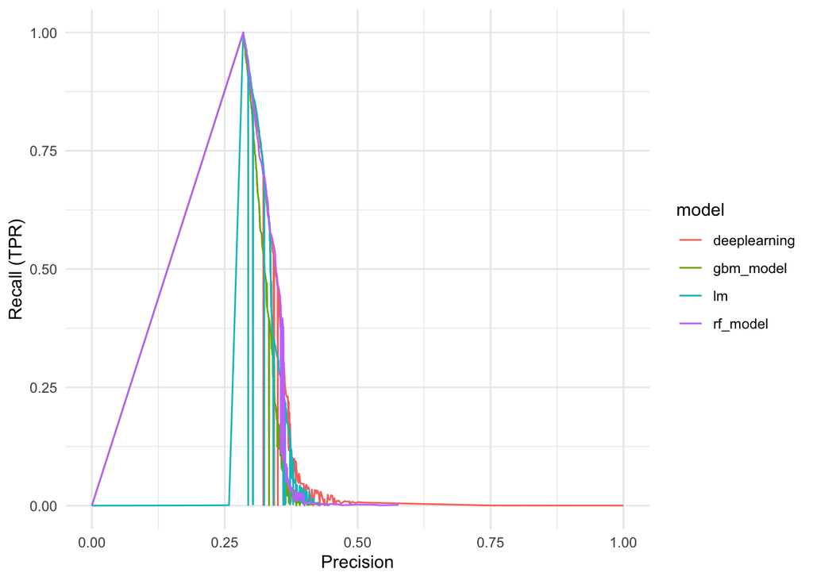

```r
plotRP(all_performance)
```

## E, How large are the correlations of predicted scores of the validation set produced by the base learners?

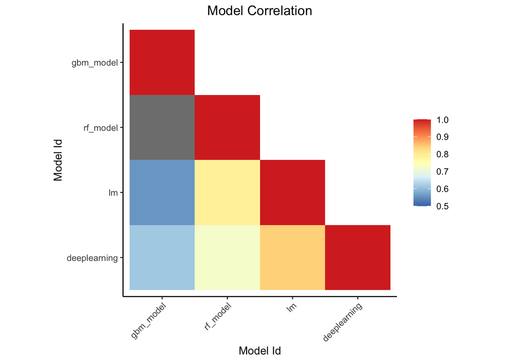

```r
h2o.model_correlation_heatmap(my_models, data_valid)
```

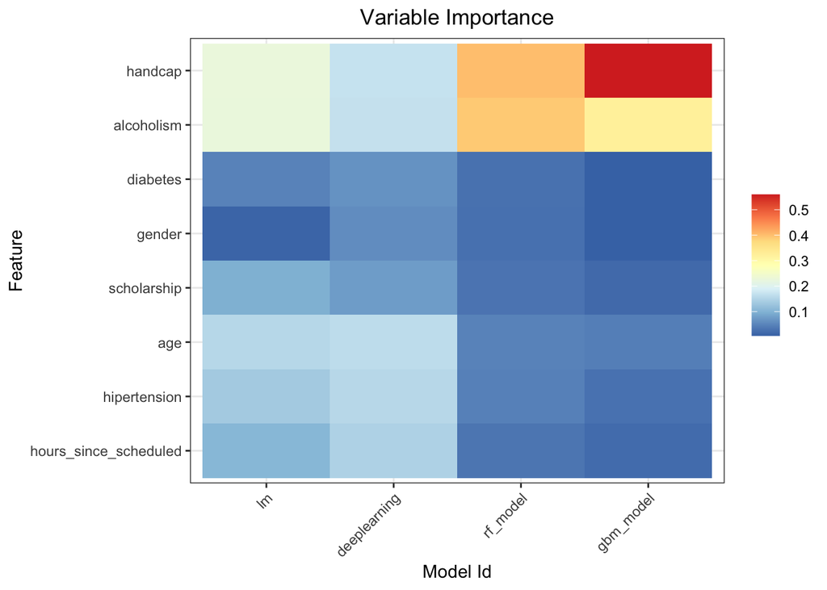

```r
h2o.varimp_heatmap(my_models)
```

It looks like the highest correlation is between the deep learning and the linear model. This is very interesting find since it can be seen that they both have a high correlation with the Rnadom Forest model as well. Since this can cause an issue when stacking, Deeplearning will not be considered for that. With the features the highest is the handcap in the GBM model, followed by handcap and alcoholism in the Random Forest. Those two features then to be the ones with the highest correlation for each of the models, meaning they are likely influencial for the classification.

## F, Create a stacked ensemble model from the base learners

```r
models_for_stacking <- list(glm_model, rf_model, gbm_model)

ensemble_model_glm <- h2o.stackedEnsemble(
  X, y,
  training_frame = data_train,
  metalearner_algorithm = 'glm',
  model_id = 'stacked_model_glm',
  base_models = models_for_stacking,
  seed = my_seed
)
ensemble_model_rf <- h2o.stackedEnsemble(
  X, y,
  training_frame = data_train,
  metalearner_algorithm = 'drf',
  model_id = 'stacked_model_rf',
  base_models = models_for_stacking,
  seed = my_seed
)
ensemble_model_gbm <- h2o.stackedEnsemble(
  X, y,
  training_frame = data_train,
  metalearner_algorithm = 'gbm',
  model_id = 'stacked_model_gbm',
  base_models = models_for_stacking,
  seed = my_seed
)
```

I wanted to see if stacking would improve the model from the base regardless of the original performance, so I build three different stacked models based on the original three very close models.

## G, Evaluate ensembles on validation set. Did it improve prediction?

```r
ensemble_models <- list(ensemble_model_glm, ensemble_model_rf, ensemble_model_gbm)
map_df(
  c(my_models, ensemble_models),
  ~{tibble(model = .@model_id, auc = h2o.auc(h2o.performance(., newdata = data_valid)))}
)
```

```
## # A tibble: 7 x 2
##   model               auc
##   <chr>             <dbl>
## 1 lm                0.578
## 2 rf_model          0.580
## 3 gbm_model         0.559
## 4 deeplearning      0.581
## 5 stacked_model_glm 0.585
## 6 stacked_model_rf  0.532
## 7 stacked_model_gbm 0.560
```

Looks like the stacked model using glm as a base is the best model since it has the highest AUC. Overall stacking improved improved the GLM and GBM models, but actually worsened the Random Forest model.

## H, Evaluate the best performing model on the test set. How does performance compare to that of the validation set?

```r
map_df(
  c(ensemble_model_glm),
  ~{tibble(model = .@model_id, auc = h2o.auc(h2o.performance(., newdata = data_test)))}
)
```

```
## # A tibble: 1 x 2
##   model               auc
##   <chr>             <dbl>
## 1 stacked_model_glm 0.585
```

The performance of the model on the test set is exactly the same as before. This is a really good sign, since that means that it should be good for generalization on this dataset.